# Credit Card Users Churn Prediction

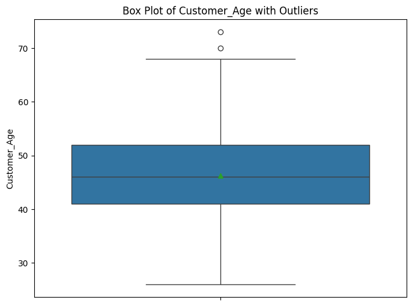

```
Outliers in column 'Customer_Age':
```

|  | Attrition_Flag | Customer_Age | Gender | Dependent_count | Education_Level | Marital_Status | Income_Category | Card_Category | Months_on_book | Total_Relationship_Count | Months_Inactive_12_mon | Contacts_Count_12_mon | Credit_Limit | Total_Revolving_Bal | Avg_Open_To_Buy | Total_Amt_Chng_Q4_Q1 | Total_Trans_Amt | Total_Trans_Ct | Total_Ct_Chng_Q4_Q1 | Avg_Utilization_Ratio |
| --- | --- | --- | --- | --- | --- | --- | --- | --- | --- | --- | --- | --- | --- | --- | --- | --- | --- | --- | --- | --- |
| 251 | 0 | 73 | M | 0 | High School | Married | $40K - $60K | Blue | 36 | 5 | 3 | 2 | 4469.000 | 1125 | 3344.000 | 1.363 | 1765 | 34 | 1.615 | 0.252 |
| 254 | 0 | 70 | M | 0 | High School | Married | Less than $40K | Blue | 56 | 3 | 2 | 3 | 3252.000 | 1495 | 1757.000 | 0.581 | 1227 | 15 | 0.875 | 0.460 |

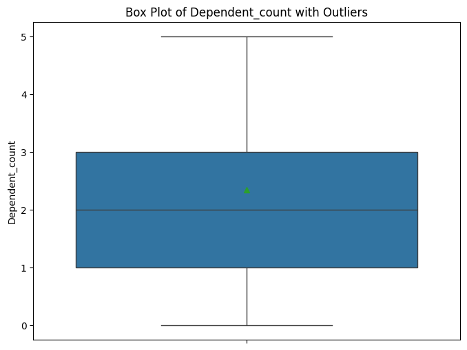

```
Outliers in column 'Dependent_count':
```

|  | Attrition_Flag | Customer_Age | Gender | Dependent_count | Education_Level | Marital_Status | Income_Category | Card_Category | Months_on_book | Total_Relationship_Count | Months_Inactive_12_mon | Contacts_Count_12_mon | Credit_Limit | Total_Revolving_Bal | Avg_Open_To_Buy | Total_Amt_Chng_Q4_Q1 | Total_Trans_Amt | Total_Trans_Ct | Total_Ct_Chng_Q4_Q1 | Avg_Utilization_Ratio |
| --- | --- | --- | --- | --- | --- | --- | --- | --- | --- | --- | --- | --- | --- | --- | --- | --- | --- | --- | --- | --- |

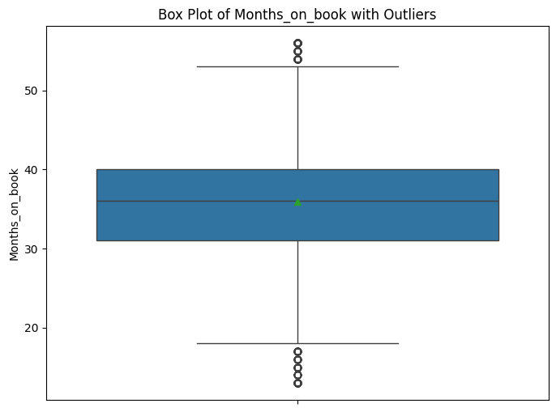

```
Outliers in column 'Months_on_book':
```

|  | Attrition_Flag | Customer_Age | Gender | Dependent_count | Education_Level | Marital_Status | Income_Category | Card_Category | Months_on_book | Total_Relationship_Count | Months_Inactive_12_mon | Contacts_Count_12_mon | Credit_Limit | Total_Revolving_Bal | Avg_Open_To_Buy | Total_Amt_Chng_Q4_Q1 | Total_Trans_Amt | Total_Trans_Ct | Total_Ct_Chng_Q4_Q1 | Avg_Utilization_Ratio |
| --- | --- | --- | --- | --- | --- | --- | --- | --- | --- | --- | --- | --- | --- | --- | --- | --- | --- | --- | --- | --- |
| 11 | 0 | 65 | M | 1 | NaN | Married | $40K - $60K | Blue | 54 | 6 | 2 | 3 | 9095.000 | 1587 | 7508.000 | 1.433 | 1314 | 26 | 1.364 | 0.174 |
| 18 | 0 | 61 | M | 1 | High School | Married | $40K - $60K | Blue | 56 | 2 | 2 | 3 | 3193.000 | 2517 | 676.000 | 1.831 | 1336 | 30 | 1.143 | 0.788 |
| 27 | 0 | 63 | M | 1 | NaN | Married | $60K - $80K | Blue | 56 | 3 | 3 | 2 | 10215.000 | 1010 | 9205.000 | 0.843 | 1904 | 40 | 1.000 | 0.099 |
| 39 | 1 | 66 | F | 0 | Doctorate | Married | abc | Blue | 56 | 5 | 4 | 3 | 7882.000 | 605 | 7277.000 | 1.052 | 704 | 16 | 0.143 | 0.077 |
| 52 | 0 | 66 | F | 0 | High School | Married | Less than $40K | Blue | 54 | 3 | 4 | 2 | 3171.000 | 2179 | 992.000 | 1.224 | 1946 | 38 | 1.923 | 0.687 |
| ... | ... | ... | ... | ... | ... | ... | ... | ... | ... | ... | ... | ... | ... | ... | ... | ... | ... | ... | ... | ... |
| 10054 | 1 | 33 | F | 1 | Doctorate | Single | Less than $40K | Blue | 15 | 1 | 1 | 3 | 3709.000 | 1180 | 2529.000 | 0.645 | 8130 | 74 | 0.897 | 0.318 |
| 10062 | 0 | 29 | M | 2 | College | Married | $40K - $60K | Blue | 17 | 3 | 1 | 3 | 4626.000 | 1232 | 3394.000 | 0.731 | 14740 | 102 | 0.759 | 0.266 |
| 10069 | 0 | 31 | M | 2 | Graduate | Single | Less than $40K | Blue | 14 | 4 | 3 | 3 | 6933.000 | 1870 | 5063.000 | 0.656 | 15585 | 115 | 0.917 | 0.270 |
| 10107 | 1 | 61 | M | 0 | Graduate | Single | $60K - $80K | Blue | 54 | 2 | 1 | 4 | 11859.000 | 1644 | 10215.000 | 0.866 | 8930 | 79 | 0.837 | 0.139 |
| 10114 | 0 | 29 | M | 0 | Graduate | Married | Less than $40K | Blue | 15 | 3 | 1 | 5 | 4700.000 | 0 | 4700.000 | 0.617 | 14723 | 96 | 0.655 | 0.000 |

386 rows × 20 columns

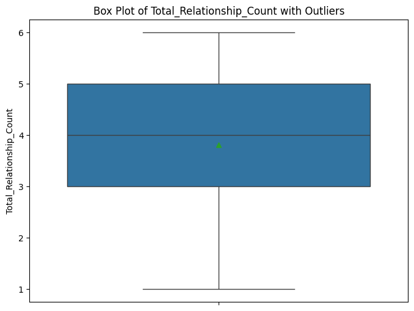

```
Outliers in column 'Total_Relationship_Count':
```

|  | Attrition_Flag | Customer_Age | Gender | Dependent_count | Education_Level | Marital_Status | Income_Category | Card_Category | Months_on_book | Total_Relationship_Count | Months_Inactive_12_mon | Contacts_Count_12_mon | Credit_Limit | Total_Revolving_Bal | Avg_Open_To_Buy | Total_Amt_Chng_Q4_Q1 | Total_Trans_Amt | Total_Trans_Ct | Total_Ct_Chng_Q4_Q1 | Avg_Utilization_Ratio |
| --- | --- | --- | --- | --- | --- | --- | --- | --- | --- | --- | --- | --- | --- | --- | --- | --- | --- | --- | --- | --- |

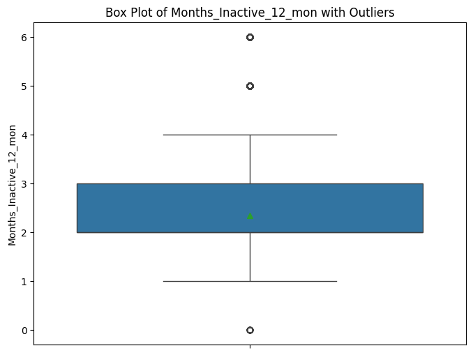

```
Outliers in column 'Months_Inactive_12_mon':
```

|  | Attrition_Flag | Customer_Age | Gender | Dependent_count | Education_Level | Marital_Status | Income_Category | Card_Category | Months_on_book | Total_Relationship_Count | Months_Inactive_12_mon | Contacts_Count_12_mon | Credit_Limit | Total_Revolving_Bal | Avg_Open_To_Buy | Total_Amt_Chng_Q4_Q1 | Total_Trans_Amt | Total_Trans_Ct | Total_Ct_Chng_Q4_Q1 | Avg_Utilization_Ratio |
| --- | --- | --- | --- | --- | --- | --- | --- | --- | --- | --- | --- | --- | --- | --- | --- | --- | --- | --- | --- | --- |
| 12 | 0 | 56 | M | 1 | College | Single | $80K - $120K | Blue | 36 | 3 | 6 | 0 | 11751.000 | 0 | 11751.000 | 3.397 | 1539 | 17 | 3.250 | 0.000 |
| 29 | 0 | 47 | M | 4 | High School | Married | $40K - $60K | Blue | 42 | 6 | 0 | 0 | 4785.000 | 1362 | 3423.000 | 0.739 | 1045 | 38 | 0.900 | 0.285 |
| 31 | 0 | 53 | M | 2 | Uneducated | Married | $60K - $80K | Blue | 48 | 2 | 5 | 1 | 2451.000 | 1690 | 761.000 | 1.323 | 1596 | 26 | 1.600 | 0.690 |
| 108 | 0 | 62 | F | 1 | NaN | Married | Less than $40K | Blue | 56 | 6 | 0 | 0 | 1438.300 | 0 | 1438.300 | 0.813 | 1951 | 44 | 1.095 | 0.000 |
| 118 | 0 | 49 | M | 1 | Doctorate | Married | $60K - $80K | Blue | 36 | 4 | 6 | 3 | 24159.000 | 1196 | 22963.000 | 0.712 | 1111 | 24 | 1.000 | 0.050 |
| ... | ... | ... | ... | ... | ... | ... | ... | ... | ... | ... | ... | ... | ... | ... | ... | ... | ... | ... | ... | ... |
| 9964 | 0 | 47 | M | 4 | NaN | Married | $60K - $80K | Blue | 36 | 4 | 5 | 2 | 10585.000 | 1749 | 8836.000 | 0.655 | 18484 | 108 | 0.588 | 0.165 |
| 10028 | 0 | 36 | F | 1 | Graduate | Single | Less than $40K | Blue | 16 | 6 | 5 | 3 | 6091.000 | 1184 | 4907.000 | 0.766 | 17437 | 113 | 0.766 | 0.194 |
| 10035 | 0 | 41 | F | 3 | Graduate | Single | Less than $40K | Blue | 36 | 4 | 6 | 2 | 4133.000 | 1067 | 3066.000 | 0.632 | 16100 | 119 | 0.608 | 0.258 |
| 10049 | 0 | 55 | M | 2 | Graduate | Married | Less than $40K | Gold | 46 | 3 | 5 | 3 | 15987.000 | 0 | 15987.000 | 0.820 | 15853 | 117 | 0.560 | 0.000 |
| 10066 | 0 | 53 | M | 2 | Uneducated | NaN | $80K - $120K | Blue | 46 | 3 | 6 | 3 | 17190.000 | 1736 | 15454.000 | 0.698 | 15055 | 117 | 0.696 | 0.101 |

331 rows × 20 columns

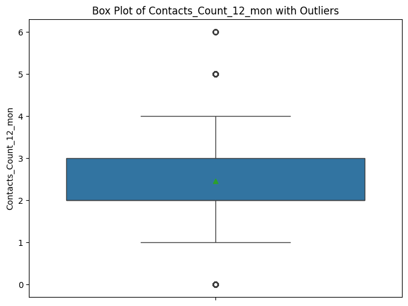

```
Outliers in column 'Contacts_Count_12_mon':
```

|  | Attrition_Flag | Customer_Age | Gender | Dependent_count | Education_Level | Marital_Status | Income_Category | Card_Category | Months_on_book | Total_Relationship_Count | Months_Inactive_12_mon | Contacts_Count_12_mon | Credit_Limit | Total_Revolving_Bal | Avg_Open_To_Buy | Total_Amt_Chng_Q4_Q1 | Total_Trans_Amt | Total_Trans_Ct | Total_Ct_Chng_Q4_Q1 | Avg_Utilization_Ratio |
| --- | --- | --- | --- | --- | --- | --- | --- | --- | --- | --- | --- | --- | --- | --- | --- | --- | --- | --- | --- | --- |
| 2 | 0 | 51 | M | 3 | Graduate | Married | $80K - $120K | Blue | 36 | 4 | 1 | 0 | 3418.000 | 0 | 3418.000 | 2.594 | 1887 | 20 | 2.333 | 0.000 |
| 4 | 0 | 40 | M | 3 | Uneducated | Married | $60K - $80K | Blue | 21 | 5 | 1 | 0 | 4716.000 | 0 | 4716.000 | 2.175 | 816 | 28 | 2.500 | 0.000 |
| 8 | 0 | 37 | M | 3 | Uneducated | Single | $60K - $80K | Blue | 36 | 5 | 2 | 0 | 22352.000 | 2517 | 19835.000 | 3.355 | 1350 | 24 | 1.182 | 0.113 |
| 12 | 0 | 56 | M | 1 | College | Single | $80K - $120K | Blue | 36 | 3 | 6 | 0 | 11751.000 | 0 | 11751.000 | 3.397 | 1539 | 17 | 3.250 | 0.000 |
| 20 | 0 | 47 | M | 1 | Doctorate | Divorced | $60K - $80K | Blue | 42 | 5 | 2 | 0 | 20979.000 | 1800 | 19179.000 | 0.906 | 1178 | 27 | 0.929 | 0.086 |
| ... | ... | ... | ... | ... | ... | ... | ... | ... | ... | ... | ... | ... | ... | ... | ... | ... | ... | ... | ... | ... |
| 10101 | 0 | 42 | M | 2 | Graduate | NaN | $40K - $60K | Blue | 30 | 3 | 2 | 5 | 3735.000 | 1723 | 2012.000 | 0.595 | 14501 | 92 | 0.840 | 0.461 |
| 10106 | 0 | 58 | F | 0 | Graduate | Single | Less than $40K | Blue | 48 | 2 | 2 | 5 | 4299.000 | 1334 | 2965.000 | 0.660 | 15068 | 123 | 0.685 | 0.310 |
| 10109 | 0 | 47 | M | 5 | High School | Single | Less than $40K | Blue | 35 | 4 | 3 | 5 | 4165.000 | 0 | 4165.000 | 0.813 | 17093 | 111 | 0.820 | 0.000 |
| 10114 | 0 | 29 | M | 0 | Graduate | Married | Less than $40K | Blue | 15 | 3 | 1 | 5 | 4700.000 | 0 | 4700.000 | 0.617 | 14723 | 96 | 0.655 | 0.000 |
| 10120 | 0 | 54 | M | 1 | High School | Single | $60K - $80K | Blue | 34 | 5 | 2 | 0 | 13940.000 | 2109 | 11831.000 | 0.660 | 15577 | 114 | 0.754 | 0.151 |

629 rows × 20 columns

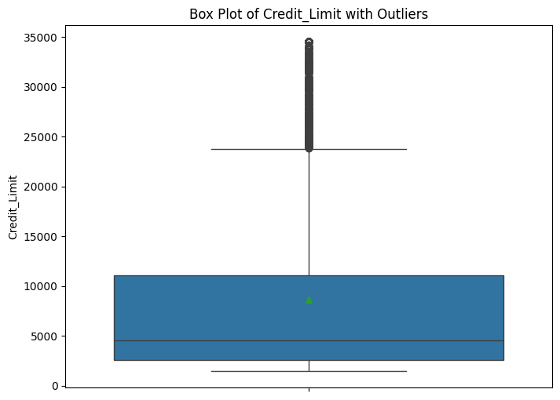

```
Outliers in column 'Credit_Limit':
```

|  | Attrition_Flag | Customer_Age | Gender | Dependent_count | Education_Level | Marital_Status | Income_Category | Card_Category | Months_on_book | Total_Relationship_Count | Months_Inactive_12_mon | Contacts_Count_12_mon | Credit_Limit | Total_Revolving_Bal | Avg_Open_To_Buy | Total_Amt_Chng_Q4_Q1 | Total_Trans_Amt | Total_Trans_Ct | Total_Ct_Chng_Q4_Q1 | Avg_Utilization_Ratio |
| --- | --- | --- | --- | --- | --- | --- | --- | --- | --- | --- | --- | --- | --- | --- | --- | --- | --- | --- | --- | --- |
| 6 | 0 | 51 | M | 4 | NaN | Married | $120K + | Gold | 46 | 6 | 1 | 3 | 34516.000 | 2264 | 32252.000 | 1.975 | 1330 | 31 | 0.722 | 0.066 |
| 7 | 0 | 32 | M | 0 | High School | NaN | $60K - $80K | Silver | 27 | 2 | 2 | 2 | 29081.000 | 1396 | 27685.000 | 2.204 | 1538 | 36 | 0.714 | 0.048 |
| 16 | 0 | 48 | M | 4 | Post-Graduate | Single | $80K - $120K | Blue | 36 | 6 | 2 | 3 | 30367.000 | 2362 | 28005.000 | 1.708 | 1671 | 27 | 0.929 | 0.078 |
| 40 | 0 | 45 | M | 3 | Graduate | Single | $80K - $120K | Blue | 41 | 2 | 2 | 2 | 32426.000 | 578 | 31848.000 | 1.042 | 1109 | 28 | 0.474 | 0.018 |
| 45 | 0 | 49 | M | 4 | Uneducated | Single | $80K - $120K | Blue | 30 | 3 | 2 | 3 | 34516.000 | 0 | 34516.000 | 1.621 | 1444 | 28 | 1.333 | 0.000 |
| ... | ... | ... | ... | ... | ... | ... | ... | ... | ... | ... | ... | ... | ... | ... | ... | ... | ... | ... | ... | ... |
| 10098 | 1 | 55 | M | 3 | Graduate | Single | $120K + | Silver | 36 | 4 | 3 | 4 | 34516.000 | 0 | 34516.000 | 1.007 | 9931 | 70 | 0.750 | 0.000 |
| 10100 | 0 | 39 | M | 2 | Graduate | NaN | $60K - $80K | Silver | 36 | 4 | 2 | 2 | 29808.000 | 0 | 29808.000 | 0.669 | 16098 | 128 | 0.684 | 0.000 |
| 10104 | 0 | 51 | M | 3 | Graduate | Single | $60K - $80K | Silver | 36 | 3 | 2 | 2 | 29663.000 | 1743 | 27920.000 | 0.667 | 14638 | 93 | 0.722 | 0.059 |
| 10110 | 0 | 56 | M | 1 | Graduate | Single | $80K - $120K | Silver | 49 | 5 | 2 | 2 | 34516.000 | 1091 | 33425.000 | 0.640 | 15274 | 108 | 0.714 | 0.032 |
| 10112 | 1 | 33 | M | 2 | College | Married | $120K + | Gold | 20 | 2 | 1 | 4 | 34516.000 | 0 | 34516.000 | 1.004 | 9338 | 73 | 0.622 | 0.000 |

984 rows × 20 columns

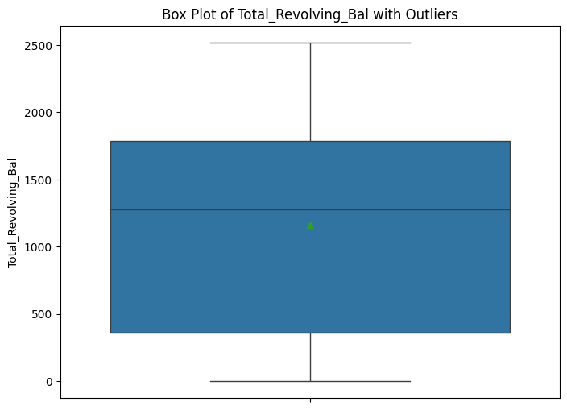

```
Outliers in column 'Total_Revolving_Bal':
```

|  | Attrition_Flag | Customer_Age | Gender | Dependent_count | Education_Level | Marital_Status | Income_Category | Card_Category | Months_on_book | Total_Relationship_Count | Months_Inactive_12_mon | Contacts_Count_12_mon | Credit_Limit | Total_Revolving_Bal | Avg_Open_To_Buy | Total_Amt_Chng_Q4_Q1 | Total_Trans_Amt | Total_Trans_Ct | Total_Ct_Chng_Q4_Q1 | Avg_Utilization_Ratio |
| --- | --- | --- | --- | --- | --- | --- | --- | --- | --- | --- | --- | --- | --- | --- | --- | --- | --- | --- | --- | --- |

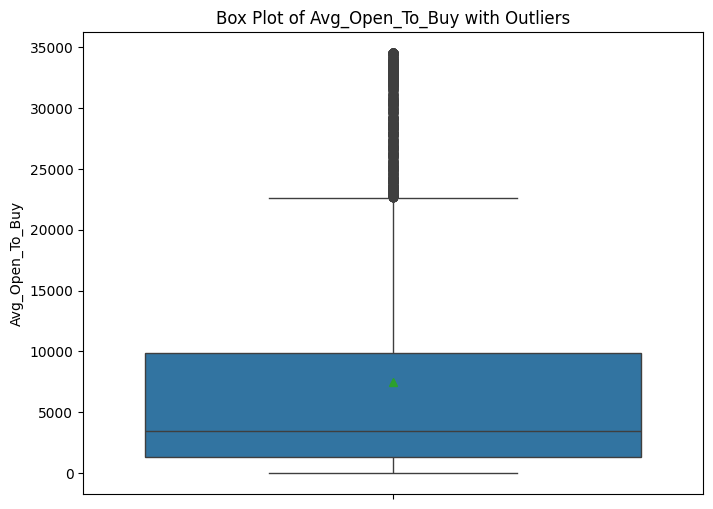

```
Outliers in column 'Avg_Open_To_Buy':
```

|  | Attrition_Flag | Customer_Age | Gender | Dependent_count | Education_Level | Marital_Status | Income_Category | Card_Category | Months_on_book | Total_Relationship_Count | Months_Inactive_12_mon | Contacts_Count_12_mon | Credit_Limit | Total_Revolving_Bal | Avg_Open_To_Buy | Total_Amt_Chng_Q4_Q1 | Total_Trans_Amt | Total_Trans_Ct | Total_Ct_Chng_Q4_Q1 | Avg_Utilization_Ratio |
| --- | --- | --- | --- | --- | --- | --- | --- | --- | --- | --- | --- | --- | --- | --- | --- | --- | --- | --- | --- | --- |
| 6 | 0 | 51 | M | 4 | NaN | Married | $120K + | Gold | 46 | 6 | 1 | 3 | 34516.000 | 2264 | 32252.000 | 1.975 | 1330 | 31 | 0.722 | 0.066 |
| 7 | 0 | 32 | M | 0 | High School | NaN | $60K - $80K | Silver | 27 | 2 | 2 | 2 | 29081.000 | 1396 | 27685.000 | 2.204 | 1538 | 36 | 0.714 | 0.048 |
| 16 | 0 | 48 | M | 4 | Post-Graduate | Single | $80K - $120K | Blue | 36 | 6 | 2 | 3 | 30367.000 | 2362 | 28005.000 | 1.708 | 1671 | 27 | 0.929 | 0.078 |
| 40 | 0 | 45 | M | 3 | Graduate | Single | $80K - $120K | Blue | 41 | 2 | 2 | 2 | 32426.000 | 578 | 31848.000 | 1.042 | 1109 | 28 | 0.474 | 0.018 |
| 45 | 0 | 49 | M | 4 | Uneducated | Single | $80K - $120K | Blue | 30 | 3 | 2 | 3 | 34516.000 | 0 | 34516.000 | 1.621 | 1444 | 28 | 1.333 | 0.000 |
| ... | ... | ... | ... | ... | ... | ... | ... | ... | ... | ... | ... | ... | ... | ... | ... | ... | ... | ... | ... | ... |
| 10100 | 0 | 39 | M | 2 | Graduate | NaN | $60K - $80K | Silver | 36 | 4 | 2 | 2 | 29808.000 | 0 | 29808.000 | 0.669 | 16098 | 128 | 0.684 | 0.000 |
| 10103 | 1 | 51 | M | 1 | High School | Married | $80K - $120K | Blue | 36 | 4 | 3 | 4 | 22754.000 | 0 | 22754.000 | 0.799 | 8531 | 77 | 0.791 | 0.000 |
| 10104 | 0 | 51 | M | 3 | Graduate | Single | $60K - $80K | Silver | 36 | 3 | 2 | 2 | 29663.000 | 1743 | 27920.000 | 0.667 | 14638 | 93 | 0.722 | 0.059 |
| 10110 | 0 | 56 | M | 1 | Graduate | Single | $80K - $120K | Silver | 49 | 5 | 2 | 2 | 34516.000 | 1091 | 33425.000 | 0.640 | 15274 | 108 | 0.714 | 0.032 |
| 10112 | 1 | 33 | M | 2 | College | Married | $120K + | Gold | 20 | 2 | 1 | 4 | 34516.000 | 0 | 34516.000 | 1.004 | 9338 | 73 | 0.622 | 0.000 |

963 rows × 20 columns

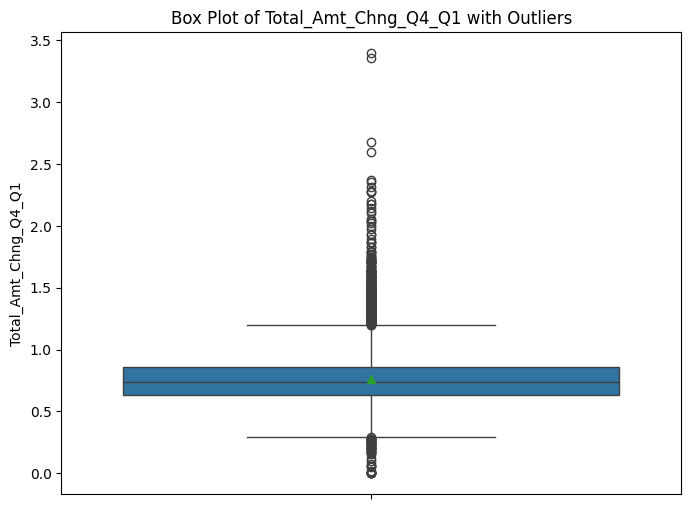

```
Outliers in column 'Total_Amt_Chng_Q4_Q1':
```

|  | Attrition_Flag | Customer_Age | Gender | Dependent_count | Education_Level | Marital_Status | Income_Category | Card_Category | Months_on_book | Total_Relationship_Count | Months_Inactive_12_mon | Contacts_Count_12_mon | Credit_Limit | Total_Revolving_Bal | Avg_Open_To_Buy | Total_Amt_Chng_Q4_Q1 | Total_Trans_Amt | Total_Trans_Ct | Total_Ct_Chng_Q4_Q1 | Avg_Utilization_Ratio |
| --- | --- | --- | --- | --- | --- | --- | --- | --- | --- | --- | --- | --- | --- | --- | --- | --- | --- | --- | --- | --- |
| 0 | 0 | 45 | M | 3 | High School | Married | $60K - $80K | Blue | 39 | 5 | 1 | 3 | 12691.000 | 777 | 11914.000 | 1.335 | 1144 | 42 | 1.625 | 0.061 |
| 1 | 0 | 49 | F | 5 | Graduate | Single | Less than $40K | Blue | 44 | 6 | 1 | 2 | 8256.000 | 864 | 7392.000 | 1.541 | 1291 | 33 | 3.714 | 0.105 |
| 2 | 0 | 51 | M | 3 | Graduate | Married | $80K - $120K | Blue | 36 | 4 | 1 | 0 | 3418.000 | 0 | 3418.000 | 2.594 | 1887 | 20 | 2.333 | 0.000 |
| 3 | 0 | 40 | F | 4 | High School | NaN | Less than $40K | Blue | 34 | 3 | 4 | 1 | 3313.000 | 2517 | 796.000 | 1.405 | 1171 | 20 | 2.333 | 0.760 |
| 4 | 0 | 40 | M | 3 | Uneducated | Married | $60K - $80K | Blue | 21 | 5 | 1 | 0 | 4716.000 | 0 | 4716.000 | 2.175 | 816 | 28 | 2.500 | 0.000 |
| ... | ... | ... | ... | ... | ... | ... | ... | ... | ... | ... | ... | ... | ... | ... | ... | ... | ... | ... | ... | ... |
| 9793 | 1 | 42 | F | 2 | Graduate | Single | $40K - $60K | Silver | 32 | 4 | 3 | 3 | 17909.000 | 0 | 17909.000 | 0.225 | 5977 | 58 | 0.487 | 0.000 |
| 9808 | 1 | 34 | M | 0 | Graduate | Divorced | $80K - $120K | Silver | 24 | 1 | 2 | 3 | 34516.000 | 400 | 34116.000 | 0.202 | 5112 | 49 | 0.256 | 0.012 |
| 9963 | 1 | 48 | M | 3 | High School | Married | $60K - $80K | Blue | 36 | 1 | 2 | 5 | 8431.000 | 0 | 8431.000 | 0.222 | 5189 | 57 | 0.357 | 0.000 |
| 10008 | 1 | 50 | M | 2 | NaN | Married | $120K + | Blue | 36 | 6 | 2 | 2 | 16081.000 | 492 | 15589.000 | 0.204 | 6100 | 61 | 0.564 | 0.031 |
| 10119 | 1 | 55 | F | 3 | Uneducated | Single | abc | Blue | 47 | 4 | 3 | 3 | 14657.000 | 2517 | 12140.000 | 0.166 | 6009 | 53 | 0.514 | 0.172 |

396 rows × 20 columns

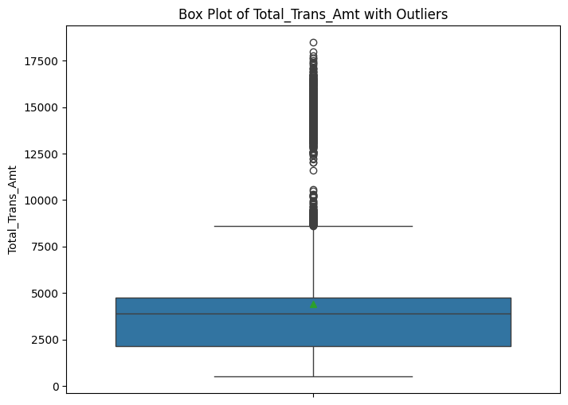

```
Outliers in column 'Total_Trans_Amt':
```

|  | Attrition_Flag | Customer_Age | Gender | Dependent_count | Education_Level | Marital_Status | Income_Category | Card_Category | Months_on_book | Total_Relationship_Count | Months_Inactive_12_mon | Contacts_Count_12_mon | Credit_Limit | Total_Revolving_Bal | Avg_Open_To_Buy | Total_Amt_Chng_Q4_Q1 | Total_Trans_Amt | Total_Trans_Ct | Total_Ct_Chng_Q4_Q1 | Avg_Utilization_Ratio |
| --- | --- | --- | --- | --- | --- | --- | --- | --- | --- | --- | --- | --- | --- | --- | --- | --- | --- | --- | --- | --- |
| 8591 | 0 | 50 | M | 3 | High School | Single | $80K - $120K | Blue | 39 | 3 | 3 | 2 | 21322.000 | 2216 | 19106.000 | 0.921 | 8693 | 91 | 0.569 | 0.104 |
| 8650 | 0 | 43 | F | 2 | College | Married | Less than $40K | Blue | 37 | 3 | 3 | 1 | 5380.000 | 1337 | 4043.000 | 0.845 | 8947 | 93 | 0.576 | 0.249 |
| 8670 | 0 | 39 | F | 4 | Doctorate | Married | Less than $40K | Blue | 27 | 2 | 1 | 1 | 8587.000 | 1324 | 7263.000 | 0.897 | 8854 | 92 | 0.643 | 0.154 |
| 8708 | 0 | 51 | F | 2 | NaN | Married | $40K - $60K | Blue | 36 | 2 | 2 | 1 | 14800.000 | 1020 | 13780.000 | 0.896 | 8796 | 94 | 0.593 | 0.069 |
| 8734 | 0 | 45 | M | 5 | NaN | Married | $60K - $80K | Blue | 38 | 1 | 2 | 3 | 6895.000 | 2314 | 4581.000 | 0.840 | 8778 | 85 | 0.604 | 0.336 |
| ... | ... | ... | ... | ... | ... | ... | ... | ... | ... | ... | ... | ... | ... | ... | ... | ... | ... | ... | ... | ... |
| 10121 | 0 | 56 | F | 1 | Graduate | Single | Less than $40K | Blue | 50 | 4 | 1 | 4 | 3688.000 | 606 | 3082.000 | 0.570 | 14596 | 120 | 0.791 | 0.164 |
| 10122 | 0 | 50 | M | 2 | Graduate | Single | $40K - $60K | Blue | 40 | 3 | 2 | 3 | 4003.000 | 1851 | 2152.000 | 0.703 | 15476 | 117 | 0.857 | 0.462 |
| 10123 | 1 | 41 | M | 2 | NaN | Divorced | $40K - $60K | Blue | 25 | 4 | 2 | 3 | 4277.000 | 2186 | 2091.000 | 0.804 | 8764 | 69 | 0.683 | 0.511 |
| 10124 | 1 | 44 | F | 1 | High School | Married | Less than $40K | Blue | 36 | 5 | 3 | 4 | 5409.000 | 0 | 5409.000 | 0.819 | 10291 | 60 | 0.818 | 0.000 |
| 10126 | 1 | 43 | F | 2 | Graduate | Married | Less than $40K | Silver | 25 | 6 | 2 | 4 | 10388.000 | 1961 | 8427.000 | 0.703 | 10294 | 61 | 0.649 | 0.189 |

896 rows × 20 columns

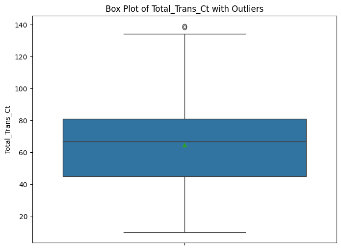

```
Outliers in column 'Total_Trans_Ct':
```

|  | Attrition_Flag | Customer_Age | Gender | Dependent_count | Education_Level | Marital_Status | Income_Category | Card_Category | Months_on_book | Total_Relationship_Count | Months_Inactive_12_mon | Contacts_Count_12_mon | Credit_Limit | Total_Revolving_Bal | Avg_Open_To_Buy | Total_Amt_Chng_Q4_Q1 | Total_Trans_Amt | Total_Trans_Ct | Total_Ct_Chng_Q4_Q1 | Avg_Utilization_Ratio |
| --- | --- | --- | --- | --- | --- | --- | --- | --- | --- | --- | --- | --- | --- | --- | --- | --- | --- | --- | --- | --- |
| 9324 | 0 | 41 | M | 3 | NaN | Married | $120K + | Blue | 33 | 2 | 4 | 3 | 34516.000 | 638 | 33878.000 | 0.724 | 13085 | 139 | 0.675 | 0.018 |
| 9586 | 0 | 56 | F | 1 | High School | Married | abc | Blue | 49 | 1 | 2 | 1 | 17542.000 | 2517 | 15025.000 | 0.800 | 13939 | 138 | 0.792 | 0.143 |

[2 more figures not shown]

```
Outliers in column 'Avg_Utilization_Ratio':
```

|  | Attrition_Flag | Customer_Age | Gender | Dependent_count | Education_Level | Marital_Status | Income_Category | Card_Category | Months_on_book | Total_Relationship_Count | Months_Inactive_12_mon | Contacts_Count_12_mon | Credit_Limit | Total_Revolving_Bal | Avg_Open_To_Buy | Total_Amt_Chng_Q4_Q1 | Total_Trans_Amt | Total_Trans_Ct | Total_Ct_Chng_Q4_Q1 | Avg_Utilization_Ratio |
| --- | --- | --- | --- | --- | --- | --- | --- | --- | --- | --- | --- | --- | --- | --- | --- | --- | --- | --- | --- | --- |

```python
cols = list(data.select_dtypes(include=["float64", "int64"]))
cols.remove("Attrition_Flag")
identify_plot_outliers(data, cols)
```

### 3.2. Dataset split: train-validation-test

Avoiding Data Leakage:

- Data dictionary was evaluated and no feature was identified that could result in data leakage.
- Missing value Imputation:
  - train-validation-test splits are created before performing any imputation.
  - fit_transform will be performed only on the train split.
  - transform will be performed only on the val/test split.

```python
# replacing 'abc' with NaN

data["Income_Category"].replace("abc", np.nan, inplace=True)
data.isna().sum()

# creating an instace of the imputer to be used
imputer = SimpleImputer(strategy="most_frequent")
```

```python
# Dividing train data into X and y

X = data.drop(["Attrition_Flag"], axis=1)
y = data["Attrition_Flag"]
```

```python
# Splitting data into training, validation and test set: 70/15/15

X_train, X_temp, y_train, y_temp = train_test_split(X, y, test_size=0.3, random_state=my_random_state, stratify=y)

X_val, X_test, y_val, y_test = train_test_split(X_temp, y_temp, test_size=0.5, random_state=my_random_state, stratify=y_temp)

print(X_train.shape, X_val.shape, X_test.shape)
```

```
(7088, 19) (1519, 19) (1520, 19)
```

### 3.3. Missing value imputation

Missing values are likely due to structured data collection gaps rather than random missingness, and the most frequent value reflects dominant patterns in the dataset, using SimpleImputer(strategy="most_frequent") ensures minimal distortion while preserving predictive power.

```python
reqd_col_for_impute = ["Education_Level", "Marital_Status", "Income_Category"]
```

```python
# Fit and transform the train split
X_train[reqd_col_for_impute] = imputer.fit_transform(X_train[reqd_col_for_impute])

# validation split, only transform
X_val[reqd_col_for_impute]  =  imputer.transform(X_val[reqd_col_for_impute])

# test split, only transform
X_test[reqd_col_for_impute] = imputer.transform(X_test[reqd_col_for_impute])
```

```python
# Checking that no column has missing values in train or test sets
print(X_train.isna().sum())
print("-" * 30)
print(X_val.isna().sum())
print("-" * 30)
print(X_test.isna().sum())
```

```
Customer_Age                0
Gender                      0
Dependent_count             0
Education_Level             0
Marital_Status              0
Income_Category             0
Card_Category               0
Months_on_book              0
Total_Relationship_Count    0
Months_Inactive_12_mon      0
Contacts_Count_12_mon       0
Credit_Limit                0
Total_Revolving_Bal         0
Avg_Open_To_Buy             0
Total_Amt_Chng_Q4_Q1        0
Total_Trans_Amt             0
Total_Trans_Ct              0
Total_Ct_Chng_Q4_Q1         0
Avg_Utilization_Ratio       0
dtype: int64
------------------------------
Customer_Age                0
Gender                      0
Dependent_count             0
Education_Level             0
Marital_Status              0
Income_Category             0
Card_Category               0
Months_on_book              0
Total_Relationship_Count    0
Months_Inactive_12_mon      0
Contacts_Count_12_mon       0
Credit_Limit                0
Total_Revolving_Bal         0
Avg_Open_To_Buy             0
Total_Amt_Chng_Q4_Q1        0
Total_Trans_Amt             0
Total_Trans_Ct              0
Total_Ct_Chng_Q4_Q1         0
Avg_Utilization_Ratio       0
dtype: int64
------------------------------
Customer_Age                0
Gender                      0
Dependent_count             0
Education_Level             0
Marital_Status              0
Income_Category             0
Card_Category               0
Months_on_book              0
Total_Relationship_Count    0
Months_Inactive_12_mon      0
Contacts_Count_12_mon       0
Credit_Limit                0
Total_Revolving_Bal         0
Avg_Open_To_Buy             0
Total_Amt_Chng_Q4_Q1        0
Total_Trans_Amt             0
Total_Trans_Ct              0
Total_Ct_Chng_Q4_Q1         0
Avg_Utilization_Ratio       0
dtype: int64
```

```python
cols = X_train.select_dtypes(include=["object", "category"])
for i in cols.columns:
    print(X_train[i].value_counts())
    print("*" * 30)
```

```
F    3759
M    3329
Name: Gender, dtype: int64
Graduate         3227
High School      1455
Uneducated       1035
College           690
Post-Graduate     368
Doctorate         313
Name: Education_Level, dtype: int64
Married     3803
Single      2766
Divorced     519
Name: Marital_Status, dtype: int64
Less than $40K    3280
$40K - $60K       1257
$80K - $120K      1068
$60K - $80K        965
$120K +            518
Name: Income_Category, dtype: int64
Blue        6604
Silver       385
Gold          85
Platinum      14
Name: Card_Category, dtype: int64
```

```python
cols = X_val.select_dtypes(include=["object", "category"])
for i in cols.columns:
    print(X_val[i].value_counts())
    print("*" * 30)
```

```
F    788
M    731
Name: Gender, dtype: int64
Graduate         720
High School      261
Uneducated       222
College          159
Post-Graduate     87
Doctorate         70
Name: Education_Level, dtype: int64
Married     818
Single      586
Divorced    115
Name: Marital_Status, dtype: int64
Less than $40K    688
$40K - $60K       256
$80K - $120K      247
$60K - $80K       220
$120K +           108
Name: Income_Category, dtype: int64
Blue        1422
Silver        81
Gold          14
Platinum       2
Name: Card_Category, dtype: int64
```

```python
cols = X_test.select_dtypes(include=["object", "category"])
for i in cols.columns:
    print(X_train[i].value_counts())
    print("*" * 30)
```

```
F    3759
M    3329
Name: Gender, dtype: int64
Graduate         3227
High School      1455
Uneducated       1035
College           690
Post-Graduate     368
Doctorate         313
Name: Education_Level, dtype: int64
Married     3803
Single      2766
Divorced     519
Name: Marital_Status, dtype: int64
Less than $40K    3280
$40K - $60K       1257
$80K - $120K      1068
$60K - $80K        965
$120K +            518
Name: Income_Category, dtype: int64
Blue        6604
Silver       385
Gold          85
Platinum      14
Name: Card_Category, dtype: int64
```

### 3.4. Encoding categorical variables

```python
X_train = pd.get_dummies(X_train, drop_first=True)
X_train = X_train.astype('float')

X_val = pd.get_dummies(X_val, drop_first=True)
X_val = X_val.astype('float')

X_test = pd.get_dummies(X_test, drop_first=True)
X_test = X_test.astype('float')

print(X_train.shape, X_val.shape, X_test.shape)
```

```
(7088, 29) (1519, 29) (1520, 29)
```

## 4. MODEL BUILDING

### 4.1. Model evaluation criterion

**Which metric to optimize?**

**Let's define a function to output different metrics (including recall) on the train and test set and a function to show confusion matrix so that we do not have to use the same code repetitively while evaluating models.**

```python
# defining a function to compute different metrics to check performance of a classification model built using sklearn
def model_performance_classification_sklearn(model, predictors, target):
    """
    Function to compute different metrics to check classification model performance

    model: classifier
    predictors: independent variables
    target: dependent variable
    """

    # predicting using the independent variables
    pred = model.predict(predictors)

    acc = accuracy_score(target, pred)  # to compute Accuracy
    recall = recall_score(target, pred)  # to compute Recall
    precision = precision_score(target, pred)  # to compute Precision
    f1 = f1_score(target, pred)  # to compute F1-score

    # creating a dataframe of metrics
    df_perf = pd.DataFrame(
        {
            "Accuracy": acc,
            "Recall": recall,
            "Precision": precision,
            "F1": f1

        },
        index=[0],
    )

    return df_perf
```

```python
def confusion_matrix_sklearn(model, predictors, target):
    """
    To plot the confusion_matrix with percentages

    model: classifier
    predictors: independent variables
    target: dependent variable
    """
    y_pred = model.predict(predictors)
    cm = confusion_matrix(target, y_pred)
    labels = np.asarray(
        [
            ["{0:0.0f}".format(item) + "\n{0:.2%}".format(item / cm.flatten().sum())]
            for item in cm.flatten()
        ]
    ).reshape(2, 2)

    plt.figure(figsize=(6, 4))
    sns.heatmap(cm, annot=labels, fmt="")
    plt.ylabel("True label")
    plt.xlabel("Predicted label")
```

```python
def multiple_models_train_val(models, prefix, dataset_type, X_split, y_split):
  """
  To train multiple models on custom training split, and evaluate them in the validation split.

  * models: list of models
  * prefix: prefix of the model name, eg. 'os_' for oversampled data, 'us_' for undersampled data
  * dataset_type: type of dataset, eg. 'original', 'oversampled', 'undersampled'
  * X_split: training data, e.g. original data, oversampled data, undersampled data
  * y_split: training labels, e.g. original data, oversampled data, undersampled data
  """

  results = []

  # training performance
  for name, model in models:
      if name.startswith(prefix):  # run only for the current prefix

        # training on current data split
        model.fit(X_split, y_split)

        # predicting on current data split
        acc = accuracy_score(y_split, model.predict(X_split))
        recall = recall_score(y_split, model.predict(X_split))
        precision = precision_score(y_split, model.predict(X_split))
        f1 = f1_score(y_split, model.predict(X_split))
        results.append([name, dataset_type, "train", recall, acc, precision, f1])


  # validation performance

  for name, model in models:
      if name.startswith(prefix):  # run only for the current prefix

        # training on current data split
        model.fit(X_split, y_split)

        # predicting on validation split
        acc = accuracy_score(y_val, model.predict(X_val))
        recall = recall_score(y_val, model.predict(X_val))
        precision = precision_score(y_val, model.predict(X_val))
        f1 = f1_score(y_val, model.predict(X_val))
        results.append([name, dataset_type, "val", recall, acc, precision, f1])


  # Create a Pandas DataFrame from the results list
  results_df = pd.DataFrame(results, columns=["model_name", "dataset", "split", "recall", "accuracy", "precision", "f1"])

  # Set display options to show all decimal places
  pd.set_option("display.float_format", lambda x: str(x))

  return results_df
```

```python
# Search the 'models' array based on the name
def find_model(models, name):
  for model_name, model in models:
    if model_name == name:
      return model
  return None
```

### 4.2. Model Building with **original data**

```python
models = []  # Empty list to store all the models
```

```python
# Appending models into the list

prefix = "od_" # for original data

models.append((prefix + "dt", DecisionTreeClassifier
(random_state=my_random_state) ))
models.append((prefix + "rf", RandomForestClassifier(random_state=my_random_state)))
models.append((prefix + "bagging", BaggingClassifier(random_state=my_random_state)))
models.append((prefix + "ada", AdaBoostClassifier(random_state=my_random_state) ))
models.append((prefix + "xgb", XGBClassifier(random_state=my_random_state) ))

results_od = multiple_models_train_val(models, prefix, "original", X_train, y_train)
results_od.sort_values(by="recall", ascending=False)
```

|  | model_name | dataset | split | recall | accuracy | precision | f1 |
| --- | --- | --- | --- | --- | --- | --- | --- |
| 0 | od_dt | original | train | 1.0 | 1.0 | 1.0 | 1.0 |
| 1 | od_rf | original | train | 1.0 | 1.0 | 1.0 | 1.0 |
| 4 | od_xgb | original | train | 1.0 | 1.0 | 1.0 | 1.0 |
| 2 | od_bagging | original | train | 0.9859525899912204 | 0.9970372460496614 | 0.9955673758865248 | 0.9907366563740626 |
| 3 | od_ada | original | train | 0.8700614574187884 | 0.9640237020316027 | 0.9025500910746812 | 0.886008046490836 |
| 9 | od_xgb | original | val | 0.860655737704918 | 0.967741935483871 | 0.9333333333333333 | 0.8955223880597015 |
| 8 | od_ada | original | val | 0.8237704918032787 | 0.9572086899275839 | 0.9013452914798207 | 0.860813704496788 |
| 7 | od_bagging | original | val | 0.8073770491803278 | 0.9526003949967083 | 0.8873873873873874 | 0.8454935622317596 |
| 5 | od_dt | original | val | 0.7827868852459017 | 0.9374588545095458 | 0.8197424892703863 | 0.80083857442348 |
| 6 | od_rf | original | val | 0.7786885245901639 | 0.9532587228439763 | 0.9178743961352657 | 0.8425720620842572 |

### 4.3. Model Building with **Oversampled data**

```python
print("Before Oversampling, counts of label 'Yes': {}".format(sum(y_train == 1)))
print("Before Oversampling, counts of label 'No': {} \n".format(sum(y_train == 0)))

sm = SMOTE(
    sampling_strategy=1, k_neighbors=5, random_state=my_random_state
)  # Synthetic Minority Over Sampling Technique
X_train_over, y_train_over = sm.fit_resample(X_train, y_train)


print("After Oversampling, counts of label 'Yes': {}".format(sum(y_train_over == 1)))
print("After Oversampling, counts of label 'No': {} \n".format(sum(y_train_over == 0)))


print("After Oversampling, the shape of train_X: {}".format(X_train_over.shape))
print("After Oversampling, the shape of train_y: {} \n".format(y_train_over.shape))
```

```
Before Oversampling, counts of label 'Yes': 1139
Before Oversampling, counts of label 'No': 5949

After Oversampling, counts of label 'Yes': 5949
After Oversampling, counts of label 'No': 5949

After Oversampling, the shape of train_X: (11898, 29)
After Oversampling, the shape of train_y: (11898,)
```

```python
prefix = "os_" # for over sampled

# Appending models into the list
models.append((prefix + "dt", DecisionTreeClassifier
(random_state=my_random_state) ))
models.append((prefix + "rf", RandomForestClassifier(random_state=my_random_state)))
models.append((prefix + "bagging", BaggingClassifier(random_state=my_random_state)))
models.append((prefix + "ada", AdaBoostClassifier(random_state=my_random_state) ))
models.append((prefix + "xgb", XGBClassifier(random_state=my_random_state) ))

results_os = multiple_models_train_val(models, prefix, "oversampled",X_train_over, y_train_over)
results_os.sort_values(by="recall", ascending=False)
```

|  | model_name | dataset | split | recall | accuracy | precision | f1 |
| --- | --- | --- | --- | --- | --- | --- | --- |
| 0 | os_dt | oversampled | train | 1.0 | 1.0 | 1.0 | 1.0 |
| 1 | os_rf | oversampled | train | 1.0 | 1.0 | 1.0 | 1.0 |
| 4 | os_xgb | oversampled | train | 1.0 | 1.0 | 1.0 | 1.0 |
| 2 | os_bagging | oversampled | train | 0.9979828542612204 | 0.9984871406959153 | 0.9989904088844018 | 0.9984863773965691 |
| 3 | os_ada | oversampled | train | 0.9732728189611699 | 0.9710875777441587 | 0.9690376569037656 | 0.9711506205971151 |
| 9 | os_xgb | oversampled | val | 0.8811475409836066 | 0.9690585911784069 | 0.9227467811158798 | 0.9014675052410901 |
| 8 | os_ada | oversampled | val | 0.8688524590163934 | 0.946017116524029 | 0.8091603053435115 | 0.8379446640316206 |
| 6 | os_rf | oversampled | val | 0.819672131147541 | 0.9539170506912442 | 0.8849557522123894 | 0.851063829787234 |
| 7 | os_bagging | oversampled | val | 0.8114754098360656 | 0.9473337722185649 | 0.853448275862069 | 0.8319327731092437 |
| 5 | os_dt | oversampled | val | 0.7581967213114754 | 0.9249506254114549 | 0.7708333333333334 | 0.7644628099173554 |

### 4.4. Model Building with **Undersampled data**

```python
# Random undersampler for under sampling the data
rus = RandomUnderSampler(random_state=my_random_state, sampling_strategy=1)
X_train_under, y_train_under = rus.fit_resample(X_train, y_train)
```

```python
print("Before Under Sampling, counts of label 'Yes': {}".format(sum(y_train == 1)))
print("Before Under Sampling, counts of label 'No': {} \n".format(sum(y_train == 0)))

print("After Under Sampling, counts of label 'Yes': {}".format(sum(y_train_under == 1)))
print("After Under Sampling, counts of label 'No': {} \n".format(sum(y_train_under == 0)))

print("After Under Sampling, the shape of train_X: {}".format(X_train_under.shape))
print("After Under Sampling, the shape of train_y: {} \n".format(y_train_under.shape))
```

```
Before Under Sampling, counts of label 'Yes': 1139
Before Under Sampling, counts of label 'No': 5949

After Under Sampling, counts of label 'Yes': 1139
After Under Sampling, counts of label 'No': 1139

After Under Sampling, the shape of train_X: (2278, 29)
After Under Sampling, the shape of train_y: (2278,)
```

```python
prefix = "us_" # for under sampled

# Appending models into the list
models.append((prefix + "dt", DecisionTreeClassifier
(random_state=my_random_state) ))
models.append((prefix + "rf", RandomForestClassifier(random_state=my_random_state)))
models.append((prefix + "bagging", BaggingClassifier(random_state=my_random_state)))
models.append((prefix + "ada", AdaBoostClassifier(random_state=my_random_state) ))
models.append((prefix + "xgb", XGBClassifier(random_state=my_random_state) ))

results_us = multiple_models_train_val(models, prefix, "undersampled",X_train_under, y_train_under)
results_us.sort_values(by="recall", ascending=False)
```

|  | model_name | dataset | split | recall | accuracy | precision | f1 |
| --- | --- | --- | --- | --- | --- | --- | --- |
| 0 | us_dt | undersampled | train | 1.0 | 1.0 | 1.0 | 1.0 |
| 1 | us_rf | undersampled | train | 1.0 | 1.0 | 1.0 | 1.0 |
| 4 | us_xgb | undersampled | train | 1.0 | 1.0 | 1.0 | 1.0 |
| 2 | us_bagging | undersampled | train | 0.9894644424934153 | 0.9934152765583846 | 0.9973451327433628 | 0.9933891582194799 |
| 9 | us_xgb | undersampled | val | 0.9672131147540983 | 0.9512837393021725 | 0.7814569536423841 | 0.8644688644688645 |
| 3 | us_ada | undersampled | train | 0.9587357330992098 | 0.9521510096575944 | 0.9462738301559792 | 0.9524640209332752 |
| 8 | us_ada | undersampled | val | 0.9549180327868853 | 0.9361421988150099 | 0.7304075235109718 | 0.827708703374778 |
| 6 | us_rf | undersampled | val | 0.9508196721311475 | 0.9407504937458855 | 0.7483870967741936 | 0.8375451263537906 |
| 5 | us_dt | undersampled | val | 0.9221311475409836 | 0.8992758393680053 | 0.6267409470752089 | 0.746268656716418 |
| 7 | us_bagging | undersampled | val | 0.889344262295082 | 0.9368005266622779 | 0.7587412587412588 | 0.8188679245283019 |

### 4.5. Model building - conclusions

```python
results_all_datasets = pd.concat([results_od, results_os, results_us], ignore_index=True)
results_all_datasets.sort_values(by="recall", ascending=False)
```

|  | model_name | dataset | split | recall | accuracy | precision | f1 |
| --- | --- | --- | --- | --- | --- | --- | --- |
| 0 | od_dt | original | train | 1.0 | 1.0 | 1.0 | 1.0 |
| 24 | us_xgb | undersampled | train | 1.0 | 1.0 | 1.0 | 1.0 |
| 4 | od_xgb | original | train | 1.0 | 1.0 | 1.0 | 1.0 |
| 21 | us_rf | undersampled | train | 1.0 | 1.0 | 1.0 | 1.0 |
| 20 | us_dt | undersampled | train | 1.0 | 1.0 | 1.0 | 1.0 |
| 1 | od_rf | original | train | 1.0 | 1.0 | 1.0 | 1.0 |
| 14 | os_xgb | oversampled | train | 1.0 | 1.0 | 1.0 | 1.0 |
| 10 | os_dt | oversampled | train | 1.0 | 1.0 | 1.0 | 1.0 |
| 11 | os_rf | oversampled | train | 1.0 | 1.0 | 1.0 | 1.0 |
| 12 | os_bagging | oversampled | train | 0.9979828542612204 | 0.9984871406959153 | 0.9989904088844018 | 0.9984863773965691 |
| 22 | us_bagging | undersampled | train | 0.9894644424934153 | 0.9934152765583846 | 0.9973451327433628 | 0.9933891582194799 |
| 2 | od_bagging | original | train | 0.9859525899912204 | 0.9970372460496614 | 0.9955673758865248 | 0.9907366563740626 |
| 13 | os_ada | oversampled | train | 0.9732728189611699 | 0.9710875777441587 | 0.9690376569037656 | 0.9711506205971151 |
| 29 | us_xgb | undersampled | val | 0.9672131147540983 | 0.9512837393021725 | 0.7814569536423841 | 0.8644688644688645 |
| 23 | us_ada | undersampled | train | 0.9587357330992098 | 0.9521510096575944 | 0.9462738301559792 | 0.9524640209332752 |
| 28 | us_ada | undersampled | val | 0.9549180327868853 | 0.9361421988150099 | 0.7304075235109718 | 0.827708703374778 |
| 26 | us_rf | undersampled | val | 0.9508196721311475 | 0.9407504937458855 | 0.7483870967741936 | 0.8375451263537906 |
| 25 | us_dt | undersampled | val | 0.9221311475409836 | 0.8992758393680053 | 0.6267409470752089 | 0.746268656716418 |
| 27 | us_bagging | undersampled | val | 0.889344262295082 | 0.9368005266622779 | 0.7587412587412588 | 0.8188679245283019 |
| 19 | os_xgb | oversampled | val | 0.8811475409836066 | 0.9690585911784069 | 0.9227467811158798 | 0.9014675052410901 |
| 3 | od_ada | original | train | 0.8700614574187884 | 0.9640237020316027 | 0.9025500910746812 | 0.886008046490836 |
| 18 | os_ada | oversampled | val | 0.8688524590163934 | 0.946017116524029 | 0.8091603053435115 | 0.8379446640316206 |
| 9 | od_xgb | original | val | 0.860655737704918 | 0.967741935483871 | 0.9333333333333333 | 0.8955223880597015 |
| 8 | od_ada | original | val | 0.8237704918032787 | 0.9572086899275839 | 0.9013452914798207 | 0.860813704496788 |
| 16 | os_rf | oversampled | val | 0.819672131147541 | 0.9539170506912442 | 0.8849557522123894 | 0.851063829787234 |
| 17 | os_bagging | oversampled | val | 0.8114754098360656 | 0.9473337722185649 | 0.853448275862069 | 0.8319327731092437 |
| 7 | od_bagging | original | val | 0.8073770491803278 | 0.9526003949967083 | 0.8873873873873874 | 0.8454935622317596 |
| 5 | od_dt | original | val | 0.7827868852459017 | 0.9374588545095458 | 0.8197424892703863 | 0.80083857442348 |
| 6 | od_rf | original | val | 0.7786885245901639 | 0.9532587228439763 | 0.9178743961352657 | 0.8425720620842572 |
| 15 | os_dt | oversampled | val | 0.7581967213114754 | 0.9249506254114549 | 0.7708333333333334 | 0.7644628099173554 |

- Models are being evaluated on Recall score. Preferring a model with high recall on validation split, and similar recall on training split, indicating good generalization.
- Several models are overfitting and displaying Recall of 100% on training split, indistinctive of original, oversampled and undersampled data.
- Best performing models and candidate for hyper parameter tuning are:
  - XGB (under sampled): 0.9672 on val, 1.0 on training
  - Random Forest (under sampled): 0.9508 on val, 1.0 on training
  - Decission Tree (under sampled): 0.9221 on val, 1.0 on training
  - Adaboost (under sampled): 0.9549 on val, 0.9587 on training
  - AdaBoost (original data): although not higher Recalls, just to add variety, this model will also be tuned. 0.8237 on val, 0.8700 on training

### 4.6. Hyperparameter Tuning

#### 4.6.0. Sample Parameter Grids

**Note**

1. Sample parameter grids have been provided to do necessary hyperparameter tuning. These sample grids are expected to provide a balance between model performance improvement and execution time. One can extend/reduce the parameter grid based on execution time and system configuration.
- Please note that if the parameter grid is extended to improve the model performance further, the execution time will increase
- For Gradient Boosting:

```
param_grid = {
    "init": [AdaBoostClassifier(random_state=my_random_state),DecisionTreeClassifier(random_state=my_random_state)],
    "n_estimators": np.arange(50,110,25),
    "learning_rate": [0.01,0.1,0.05],
    "subsample":[0.7,0.9],
    "max_features":[0.5,0.7,1],
}
```

- For Adaboost:

```
param_grid = {
    "n_estimators": np.arange(50,110,25),
    "learning_rate": [0.01,0.1,0.05],
    "base_estimator": [
        DecisionTreeClassifier(max_depth=2, random_state=my_random_state),
        DecisionTreeClassifier(max_depth=3, random_state=my_random_state),
    ],
}
```

- For Bagging Classifier:

```
param_grid = {
    'max_samples': [0.8,0.9,1],
    'max_features': [0.7,0.8,0.9],
    'n_estimators' : [30,50,70],
}
```

- For Random Forest:

```
param_grid = {
    "n_estimators": [50,110,25],
    "min_samples_leaf": np.arange(1, 4),
    "max_features": [np.arange(0.3, 0.6, 0.1),'sqrt'],
    "max_samples": np.arange(0.4, 0.7, 0.1)
}
```

- For Decision Trees:

```
param_grid = {
    'max_depth': np.arange(2,6),
    'min_samples_leaf': [1, 4, 7],
    'max_leaf_nodes' : [10, 15],
    'min_impurity_decrease': [0.0001,0.001]
}
```

- For XGBoost (optional):

```
param_grid={'n_estimators':np.arange(50,110,25),
            'scale_pos_weight':[1,2,5],
            'learning_rate':[0.01,0.1,0.05],
            'gamma':[1,3],
            'subsample':[0.7,0.9]
}
```

#### 4.6.1. XGB with undersampled data (tuned_xgb_us)

```python
%%time

# defining model
Model = XGBClassifier(random_state=my_random_state,eval_metric='logloss')

#Parameter grid to pass in RandomSearchCV
param_grid={'n_estimators':np.arange(50,110,25),
            'scale_pos_weight':[1,2,5],
            'learning_rate':[0.01,0.1,0.05],
            'gamma':[1,3],
            'subsample':[0.7,0.9]
           }

# Type of scoring used to compare parameter combinations
scorer = metrics.make_scorer(metrics.recall_score)

#Calling RandomizedSearchCV
randomized_cv = RandomizedSearchCV(estimator=Model, param_distributions=param_grid, n_iter=50, n_jobs = -1, scoring=scorer, cv=5, random_state=my_random_state)

#Fitting parameters in RandomizedSearchCV
randomized_cv.fit(X_train_under, y_train_under)

print("Best parameters are {} with CV score={}:" .format(randomized_cv.best_params_,randomized_cv.best_score_))
```

```
Best parameters are {'subsample': 0.7, 'scale_pos_weight': 5, 'n_estimators': 50, 'learning_rate': 0.01, 'gamma': 1} with CV score=0.9991228070175439:
CPU times: user 1.45 s, sys: 229 ms, total: 1.68 s
Wall time: 48.5 s
```

```python
tuned_xgb_us = XGBClassifier(
    random_state=my_random_state,
    eval_metric="logloss",
    subsample=0.7,
    scale_pos_weight=5,
    n_estimators=50,
    learning_rate=0.01,
    gamma=1,
)

tuned_xgb_us.fit(X_train_under, y_train_under)
```

```
XGBClassifier(base_score=None, booster=None, callbacks=None,
              colsample_bylevel=None, colsample_bynode=None,
              colsample_bytree=None, device=None, early_stopping_rounds=None,
              enable_categorical=False, eval_metric='logloss',
              feature_types=None, gamma=1, grow_policy=None,
              importance_type=None, interaction_constraints=None,
              learning_rate=0.01, max_bin=None, max_cat_threshold=None,
              max_cat_to_onehot=None, max_delta_step=None, max_depth=None,
              max_leaves=None, min_child_weight=None, missing=nan,
              monotone_constraints=None, multi_strategy=None, n_estimators=50,
              n_jobs=None, num_parallel_tree=None, random_state=42, ...)
```

```python
tuned_xgb_us_perf_train = model_performance_classification_sklearn(
    tuned_xgb_us, X_train_under, y_train_under)

tuned_xgb_us_perf_train
```

|  | Accuracy | Recall | Precision | F1 |
| --- | --- | --- | --- | --- |
| 0 | 0.7576821773485514 | 1.0 | 0.6735659373151981 | 0.8049469964664311 |

```python
tuned_xgb_us_perf_val = model_performance_classification_sklearn(
    tuned_xgb_us, X_val, y_val)

tuned_xgb_us_perf_val
```

|  | Accuracy | Recall | Precision | F1 |
| --- | --- | --- | --- | --- |
| 0 | 0.5562870309414089 | 1.0 | 0.2657952069716776 | 0.4199655765920826 |

#### 4.6.2. Random Forest with undersampled data (tuned_rf_us)

```python
%%time

# defining model
Model = RandomForestClassifier(random_state=my_random_state)

#Parameter grid to pass in RandomSearchCV
param_grid = {
    "n_estimators": [50,110,25],
    "min_samples_leaf": np.arange(1, 4),
    "max_features": [np.arange(0.3, 0.6, 0.1),'sqrt'],
    "max_samples": np.arange(0.4, 0.7, 0.1)
}

# Type of scoring used to compare parameter combinations
scorer = metrics.make_scorer(metrics.recall_score)

#Calling RandomizedSearchCV
randomized_cv = RandomizedSearchCV(estimator=Model, param_distributions=param_grid, n_iter=50, n_jobs = -1, scoring=scorer, cv=5, random_state=my_random_state)

#Fitting parameters in RandomizedSearchCV
randomized_cv.fit(X_train_under, y_train_under)

print("Best parameters are {} with CV score={}:" .format(randomized_cv.best_params_,randomized_cv.best_score_))
```

```
Best parameters are {'n_estimators': 110, 'min_samples_leaf': 2, 'max_samples': 0.6, 'max_features': 'sqrt'} with CV score=0.9368034624004947:
CPU times: user 900 ms, sys: 77.9 ms, total: 978 ms
Wall time: 21.2 s
```

```python
tuned_rf_us = RandomForestClassifier(
    random_state = my_random_state,
    n_estimators = 110,
    min_samples_leaf = 2,
    max_samples = 0.6,
    max_features = 'sqrt'
    )

tuned_rf_us.fit(X_train_under, y_train_under)
```

```
RandomForestClassifier(max_samples=0.6, min_samples_leaf=2, n_estimators=110,
                       random_state=42)
```

```python
tuned_rf_us_perf_train = model_performance_classification_sklearn(
    tuned_rf_us, X_train_under, y_train_under)

tuned_rf_us_perf_train
```

|  | Accuracy | Recall | Precision | F1 |
| --- | --- | --- | --- | --- |
| 0 | 0.9877085162423178 | 0.9956101843722563 | 0.9801210025929127 | 0.9878048780487805 |

```python
tuned_rf_us_perf_val = model_performance_classification_sklearn(
    tuned_rf_us, X_val, y_val)

tuned_rf_us_perf_val
```

|  | Accuracy | Recall | Precision | F1 |
| --- | --- | --- | --- | --- |
| 0 | 0.9354838709677419 | 0.9426229508196722 | 0.732484076433121 | 0.8243727598566308 |

#### 4.6.3. Decision tree with undersampled data (tuned_dt_us)

```python
%%time

# defining model
Model = DecisionTreeClassifier(random_state=my_random_state)

#Parameter grid to pass in RandomSearchCV
param_grid = {
    'max_depth': np.arange(2,6),
    'min_samples_leaf': [1, 4, 7],
    'max_leaf_nodes' : [10, 15],
    'min_impurity_decrease': [0.0001,0.001]
}

# Type of scoring used to compare parameter combinations
scorer = metrics.make_scorer(metrics.recall_score)

#Calling RandomizedSearchCV
randomized_cv = RandomizedSearchCV(estimator=Model, param_distributions=param_grid, n_iter=50, n_jobs = -1, scoring=scorer, cv=5, random_state=my_random_state)

#Fitting parameters in RandomizedSearchCV
randomized_cv.fit(X_train_under, y_train_under)

print("Best parameters are {} with CV score={}:" .format(randomized_cv.best_params_,randomized_cv.best_score_))
```

```
Best parameters are {'min_samples_leaf': 1, 'min_impurity_decrease': 0.0001, 'max_leaf_nodes': 15, 'max_depth': 5} with CV score=0.8858914908416416:
CPU times: user 208 ms, sys: 11.1 ms, total: 219 ms
Wall time: 2.55 s
```

```python
tuned_dt_us = DecisionTreeClassifier(
    random_state=my_random_state,
    max_depth = 5,
    min_samples_leaf = 1,
    max_leaf_nodes = 15,
    min_impurity_decrease = 0.0001)

tuned_dt_us.fit(X_train_under, y_train_under)
```

```
DecisionTreeClassifier(max_depth=5, max_leaf_nodes=15,
                       min_impurity_decrease=0.0001, random_state=42)
```

```python
tuned_dt_us_perf_train = model_performance_classification_sklearn(
    tuned_dt_us, X_train_under, y_train_under)

tuned_dt_us_perf_train
```

|  | Accuracy | Recall | Precision | F1 |
| --- | --- | --- | --- | --- |
| 0 | 0.9196663740122915 | 0.9069359086918349 | 0.9306306306306307 | 0.9186305024455313 |

```python
tuned_dt_us_perf_val = model_performance_classification_sklearn(
    tuned_dt_us, X_val, y_val)

tuned_dt_us_perf_val
```

|  | Accuracy | Recall | Precision | F1 |
| --- | --- | --- | --- | --- |
| 0 | 0.9084924292297564 | 0.8934426229508197 | 0.6586102719033232 | 0.7582608695652174 |

#### 4.6.4. AdaBoost with original data (tuned_ada_od)

```python
%%time

# defining model
Model = AdaBoostClassifier(random_state=my_random_state)

# Parameter grid to pass in RandomSearchCV
param_grid = {
    "n_estimators": np.arange(50,110,25),
    "learning_rate": [0.01,0.1,0.05],
    "estimator": [
        DecisionTreeClassifier(max_depth=2, random_state=my_random_state),
        DecisionTreeClassifier(max_depth=3, random_state=my_random_state),
    ],
}

# Type of scoring used to compare parameter combinations
scorer = metrics.make_scorer(metrics.recall_score)

#Calling RandomizedSearchCV
randomized_cv = RandomizedSearchCV(estimator=Model, param_distributions=param_grid, n_jobs = -1, n_iter=50, scoring=scorer, cv=5, random_state=1)

#Fitting parameters in RandomizedSearchCV
randomized_cv.fit(X_train, y_train)

print("Best parameters are {} with CV score={}:" .format(randomized_cv.best_params_,randomized_cv.best_score_))
```

```
Best parameters are {'n_estimators': 100, 'learning_rate': 0.1, 'estimator': DecisionTreeClassifier(max_depth=3, random_state=42)} with CV score=0.8604374372053482:
CPU times: user 4.52 s, sys: 235 ms, total: 4.75 s
Wall time: 2min 10s
```

```python
tuned_ada_od = AdaBoostClassifier(
    random_state=my_random_state,
    n_estimators = 100,
    learning_rate = 0.1,
    estimator = DecisionTreeClassifier(max_depth=3, random_state=my_random_state)
    )

tuned_ada_od.fit(X_train, y_train)
```

```
AdaBoostClassifier(estimator=DecisionTreeClassifier(max_depth=3,
                                                    random_state=42),
                   learning_rate=0.1, n_estimators=100, random_state=42)
```

```python
tuned_ada_od_perf_train = model_performance_classification_sklearn(
    tuned_ada_od, X_train, y_train)

tuned_ada_od_perf_train
```

|  | Accuracy | Recall | Precision | F1 |
| --- | --- | --- | --- | --- |
| 0 | 0.9853273137697517 | 0.9394205443371378 | 0.9683257918552036 | 0.9536541889483066 |

```python
tuned_ada_od_perf_val = model_performance_classification_sklearn(
    tuned_ada_od, X_val, y_val)

tuned_ada_od_perf_val
```

|  | Accuracy | Recall | Precision | F1 |
| --- | --- | --- | --- | --- |
| 0 | 0.9684002633311389 | 0.8524590163934426 | 0.9454545454545454 | 0.896551724137931 |

#### 4.6.5. AdaBoost with undersampled data (tuned_ada_us)

```python
%%time

# defining model
Model = AdaBoostClassifier(random_state=my_random_state)

# Parameter grid to pass in RandomSearchCV
param_grid = {
    "n_estimators": np.arange(50,110,25),
    "learning_rate": [0.01,0.1,0.05],
    "estimator": [
        DecisionTreeClassifier(max_depth=2, random_state=my_random_state),
        DecisionTreeClassifier(max_depth=3, random_state=my_random_state),
    ],
}

# Type of scoring used to compare parameter combinations
scorer = metrics.make_scorer(metrics.recall_score)

#Calling RandomizedSearchCV
randomized_cv = RandomizedSearchCV(estimator=Model, param_distributions=param_grid, n_jobs = -1, n_iter=50, scoring=scorer, cv=5, random_state=1)

#Fitting parameters in RandomizedSearchCV
randomized_cv.fit(X_train_under, y_train_under)

print("Best parameters are {} with CV score={}:" .format(randomized_cv.best_params_,randomized_cv.best_score_))
```

```
Best parameters are {'n_estimators': 100, 'learning_rate': 0.1, 'estimator': DecisionTreeClassifier(max_depth=2, random_state=42)} with CV score=0.9569904938557847:
CPU times: user 1.44 s, sys: 114 ms, total: 1.55 s
Wall time: 50.8 s
```

```python
tuned_ada_us = AdaBoostClassifier(
    random_state=my_random_state,
    n_estimators = 100,
    learning_rate = 0.1,
    estimator = DecisionTreeClassifier(max_depth=2, random_state=my_random_state)
    )

tuned_ada_us.fit(X_train_under, y_train_under)
```

```
AdaBoostClassifier(estimator=DecisionTreeClassifier(max_depth=2,
                                                    random_state=42),
                   learning_rate=0.1, n_estimators=100, random_state=42)
```

```python
tuned_ada_us_perf_train = model_performance_classification_sklearn(
    tuned_ada_us, X_train, y_train)

tuned_ada_us_perf_train
```

|  | Accuracy | Recall | Precision | F1 |
| --- | --- | --- | --- | --- |
| 0 | 0.9466704288939052 | 0.9780509218612818 | 0.7593728698023177 | 0.8549501151189562 |

```python
tuned_ada_us_perf_val = model_performance_classification_sklearn(
    tuned_ada_us, X_val, y_val)

tuned_ada_us_perf_val
```

|  | Accuracy | Recall | Precision | F1 |
| --- | --- | --- | --- | --- |
| 0 | 0.9407504937458855 | 0.9590163934426229 | 0.7452229299363057 | 0.8387096774193549 |

#### 4.6.6. **Going back** to default XGB with original data (default_xgb_od)

```python
default_xgb_od = XGBClassifier(random_state=my_random_state)
default_xgb_od.fit(X_train, y_train)

default_xgb_od_perf_train = model_performance_classification_sklearn(
    default_xgb_od, X_train, y_train)

default_xgb_od_perf_val = model_performance_classification_sklearn(
    default_xgb_od, X_val, y_val)

default_xgb_od_perf_test = model_performance_classification_sklearn(
    default_xgb_od, X_test, y_test)
```

## 5. MODEL COMPARISON AND FINAL MODEL SELECTION

### 5.1. Summary of performance from Train split

```python
# training performance comparison

models_comp_train = pd.concat(
    [
        tuned_xgb_us_perf_train.T,
        tuned_rf_us_perf_train.T,
        tuned_dt_us_perf_train.T,
        tuned_ada_od_perf_train.T,
        tuned_ada_us_perf_train.T,
        default_xgb_od_perf_train.T
    ],
    axis=1,
)

models_comp_train.columns = [
    "tuned_xgb_us",
    "tuned_rf_us",
    "tuned_dt_us",
    "tuned_ada_od",
    "tuned_ada_us",
    "default_xgb_od"
]

print("Training performance comparison:")
models_comp_train.T
```

```
Training performance comparison:
```

|  | Accuracy | Recall | Precision | F1 |
| --- | --- | --- | --- | --- |
| tuned_xgb_us | 0.7576821773485514 | 1.0 | 0.6735659373151981 | 0.8049469964664311 |
| tuned_rf_us | 0.9877085162423178 | 0.9956101843722563 | 0.9801210025929127 | 0.9878048780487805 |
| tuned_dt_us | 0.9196663740122915 | 0.9069359086918349 | 0.9306306306306307 | 0.9186305024455313 |
| tuned_ada_od | 0.9853273137697517 | 0.9394205443371378 | 0.9683257918552036 | 0.9536541889483066 |
| tuned_ada_us | 0.9466704288939052 | 0.9780509218612818 | 0.7593728698023177 | 0.8549501151189562 |
| default_xgb_od | 1.0 | 1.0 | 1.0 | 1.0 |

### 5.2. Summary of performance from Validation split

```python
# Validation performance comparison

models_comp_val = pd.concat(
    [
        tuned_xgb_us_perf_val.T,
        tuned_rf_us_perf_val.T,
        tuned_dt_us_perf_val.T,
        tuned_ada_od_perf_val.T,
        tuned_ada_us_perf_val.T,
        default_xgb_od_perf_val.T
    ],
    axis=1,
)

models_comp_val.columns = [
    "tuned_xgb_us",
    "tuned_rf_us",
    "tuned_dt_us",
    "tuned_ada_od",
    "tuned_ada_us",
    "default_xgb_od"
]

print("Validation performance comparison:")
models_comp_val
```

```
Validation performance comparison:
```

|  | tuned_xgb_us | tuned_rf_us | tuned_dt_us | tuned_ada_od | tuned_ada_us | default_xgb_od |
| --- | --- | --- | --- | --- | --- | --- |
| Accuracy | 0.5562870309414089 | 0.9354838709677419 | 0.9084924292297564 | 0.9684002633311389 | 0.9407504937458855 | 0.967741935483871 |
| Recall | 1.0 | 0.9426229508196722 | 0.8934426229508197 | 0.8524590163934426 | 0.9590163934426229 | 0.860655737704918 |
| Precision | 0.2657952069716776 | 0.732484076433121 | 0.6586102719033232 | 0.9454545454545454 | 0.7452229299363057 | 0.9333333333333333 |
| F1 | 0.4199655765920826 | 0.8243727598566308 | 0.7582608695652174 | 0.896551724137931 | 0.8387096774193549 | 0.8955223880597015 |

### 5.3. Test split performance

#### 5.3.1. Test - tuned XGB with undersampled data (tuned_xgb_us)

```python
tuned_xgb_us_perf_test = model_performance_classification_sklearn(
    tuned_xgb_us, X_test, y_test)

tuned_xgb_us_perf_test
```

|  | Accuracy | Recall | Precision | F1 |
| --- | --- | --- | --- | --- |
| 0 | 0.5447368421052632 | 1.0 | 0.2606837606837607 | 0.4135593220338983 |

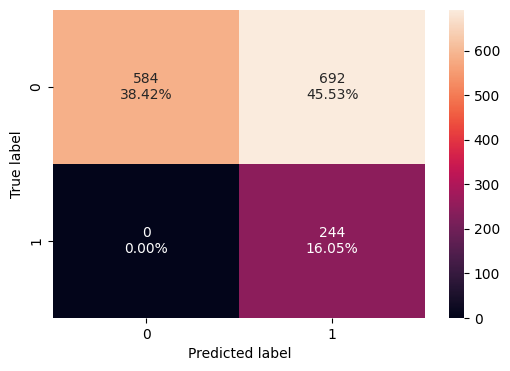

```python
confusion_matrix_sklearn(tuned_xgb_us, X_test, y_test)
```

#### 5.3.2. Test - tuned Random Forest with undersampled data (tuned_rf_us)

```python
tuned_rf_us_perf_test = model_performance_classification_sklearn(
    tuned_rf_us, X_test, y_test)

tuned_rf_us_perf_test
```

|  | Accuracy | Recall | Precision | F1 |
| --- | --- | --- | --- | --- |
| 0 | 0.9223684210526316 | 0.9098360655737705 | 0.6981132075471698 | 0.7900355871886121 |

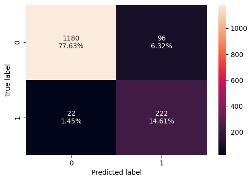

```python
confusion_matrix_sklearn(tuned_rf_us, X_test, y_test)
```

#### 5.3.3. Test - tuned Decision tree with undersampled data (tuned_dt_us)

```python
tuned_dt_us_perf_test = model_performance_classification_sklearn(
    tuned_dt_us, X_test, y_test)

tuned_dt_us_perf_test
```

|  | Accuracy | Recall | Precision | F1 |
| --- | --- | --- | --- | --- |
| 0 | 0.8940789473684211 | 0.860655737704918 | 0.6231454005934718 | 0.7228915662650602 |

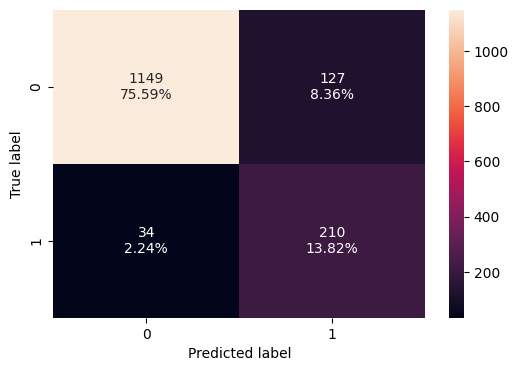

```python
confusion_matrix_sklearn(tuned_dt_us, X_test, y_test)
```

#### 5.3.4. Test - tuned AdaBoost with original data (tuned_ada_od)

```python
tuned_ada_od_perf_test = model_performance_classification_sklearn(
    tuned_ada_od, X_test, y_test)

tuned_ada_od_perf_test
```

|  | Accuracy | Recall | Precision | F1 |
| --- | --- | --- | --- | --- |
| 0 | 0.9631578947368421 | 0.8319672131147541 | 0.9311926605504587 | 0.8787878787878788 |

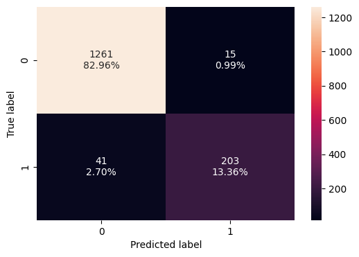

```python
confusion_matrix_sklearn(tuned_ada_od, X_test, y_test)
```

#### 5.3.5. Test - tuned AdaBoost with undersampled data (tuned_ada_us)

```python
tuned_ada_us_perf_test = model_performance_classification_sklearn(
    tuned_ada_us, X_test, y_test)

tuned_ada_us_perf_test
```

|  | Accuracy | Recall | Precision | F1 |
| --- | --- | --- | --- | --- |
| 0 | 0.9302631578947368 | 0.9344262295081968 | 0.7169811320754716 | 0.8113879003558719 |

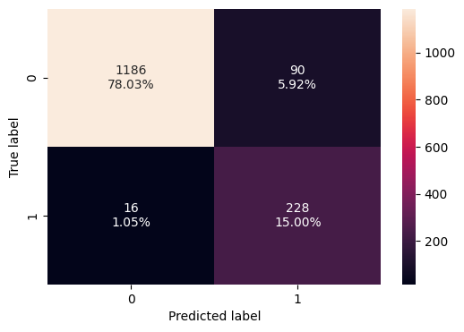

```python
confusion_matrix_sklearn(tuned_ada_us, X_test, y_test)
```

### 5.4. Comparing performance for **all splits**

```python
# Validation performance comparison

models_comp_test = pd.concat(
    [
        tuned_xgb_us_perf_test.T,
        tuned_rf_us_perf_test.T,
        tuned_dt_us_perf_test.T,
        tuned_ada_od_perf_test.T,
        tuned_ada_us_perf_test.T,
        default_xgb_od_perf_test.T
    ],
    axis=1,
)

models_comp_test.columns = [
    "tuned_xgb_us",
    "tuned_rf_us",
    "tuned_dt_us",
    "tuned_ada_od",
    "tuned_ada_us",
    "default_xgb_od"
]
```

```python
# Add a 'split' column to each DataFrame
models_comp_train['split'] = 'train'
models_comp_val['split'] = 'val'
models_comp_test['split'] = 'test'

# Concatenate the DataFrames
models_comp_all = pd.concat([models_comp_train, models_comp_val, models_comp_test])

models_comp_all
```

|  | tuned_xgb_us | tuned_rf_us | tuned_dt_us | tuned_ada_od | tuned_ada_us | default_xgb_od | split |
| --- | --- | --- | --- | --- | --- | --- | --- |
| Accuracy | 0.7576821773485514 | 0.9877085162423178 | 0.9196663740122915 | 0.9853273137697517 | 0.9466704288939052 | 1.0 | train |
| Recall | 1.0 | 0.9956101843722563 | 0.9069359086918349 | 0.9394205443371378 | 0.9780509218612818 | 1.0 | train |
| Precision | 0.6735659373151981 | 0.9801210025929127 | 0.9306306306306307 | 0.9683257918552036 | 0.7593728698023177 | 1.0 | train |
| F1 | 0.8049469964664311 | 0.9878048780487805 | 0.9186305024455313 | 0.9536541889483066 | 0.8549501151189562 | 1.0 | train |
| Accuracy | 0.5562870309414089 | 0.9354838709677419 | 0.9084924292297564 | 0.9684002633311389 | 0.9407504937458855 | 0.967741935483871 | val |
| Recall | 1.0 | 0.9426229508196722 | 0.8934426229508197 | 0.8524590163934426 | 0.9590163934426229 | 0.860655737704918 | val |
| Precision | 0.2657952069716776 | 0.732484076433121 | 0.6586102719033232 | 0.9454545454545454 | 0.7452229299363057 | 0.9333333333333333 | val |
| F1 | 0.4199655765920826 | 0.8243727598566308 | 0.7582608695652174 | 0.896551724137931 | 0.8387096774193549 | 0.8955223880597015 | val |
| Accuracy | 0.5447368421052632 | 0.9223684210526316 | 0.8940789473684211 | 0.9631578947368421 | 0.9302631578947368 | 0.9671052631578947 | test |
| Recall | 1.0 | 0.9098360655737705 | 0.860655737704918 | 0.8319672131147541 | 0.9344262295081968 | 0.8729508196721312 | test |
| Precision | 0.2606837606837607 | 0.6981132075471698 | 0.6231454005934718 | 0.9311926605504587 | 0.7169811320754716 | 0.9181034482758621 | test |
| F1 | 0.4135593220338983 | 0.7900355871886121 | 0.7228915662650602 | 0.8787878787878788 | 0.8113879003558719 | 0.8949579831932774 | test |

### 5.5. Final model selection

- `tuned XGB with undersampled data` has perfect recall on test/val/training splits, however, its other metrics are very poor. This model is likely overfitting to the minority class due to the artificially-balanced set, and performs poorly on the original imbalanced sets. Therefore this model will not be selected.
- The best performing models are (in order): `tuned Adaboost with undersampled data` and `tuned RandomForest with undersampled data`. These show high and consistent recall across test/val/training splits. Its other metrics are also good and consistent across the splits.
- `tuned Adaboost with undersampled data` will be selected as the final model with scores of:
- Test split: recall=0.9344, f1=0.81138
- Val split: recall=0.9590, f1=0.8387
- Train split: recall=0.9780, f1=0.8549

### 5.6. Feature importance

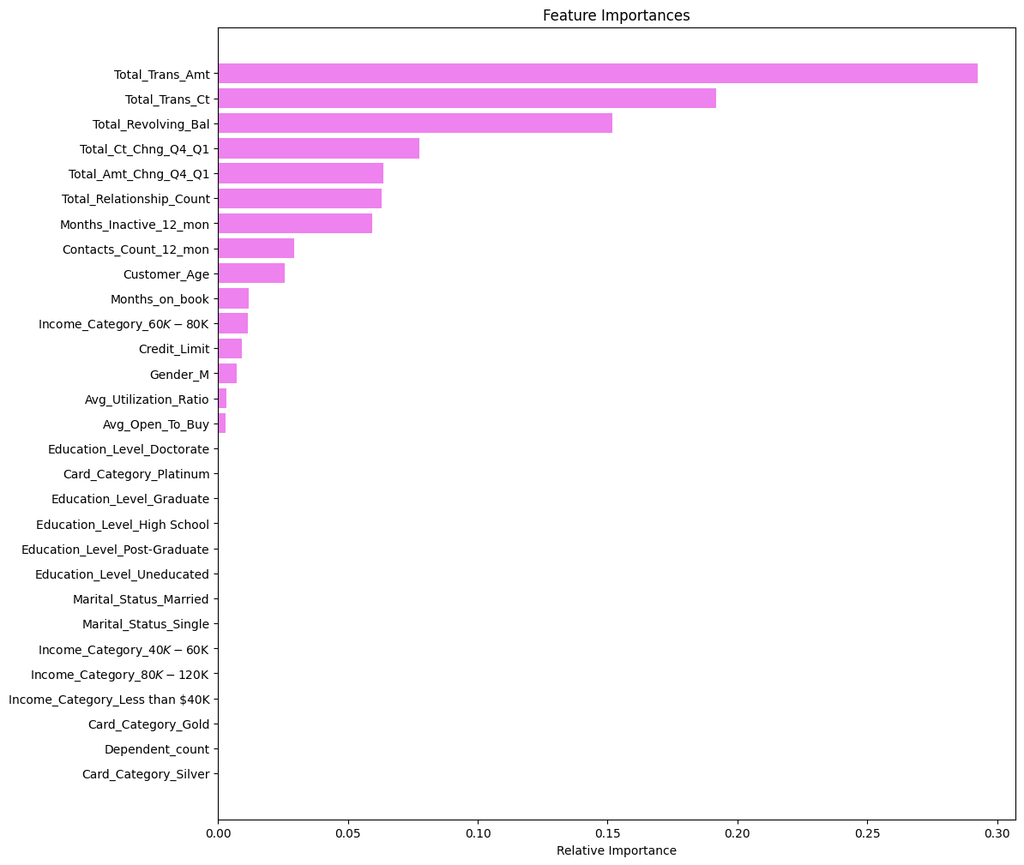

```python
feature_names = X_train.columns
importances =  tuned_ada_us.feature_importances_
indices = np.argsort(importances)

plt.figure(figsize=(12, 12))
plt.title("Feature Importances")
plt.barh(range(len(indices)), importances[indices], color="violet", align="center")
plt.yticks(range(len(indices)), [feature_names[i] for i in indices])
plt.xlabel("Relative Importance")
plt.show()
```

```python
# printed version of the feature importances, sorted in descending order

importances = tuned_ada_us.feature_importances_
feature_importances = pd.Series(importances, index=X_train.columns).sort_values(ascending=False)
print(feature_importances)
```

```
Total_Trans_Amt                    0.29254304912862517
Total_Trans_Ct                      0.1918878531864646
Total_Revolving_Bal                0.15191038108238872
Total_Ct_Chng_Q4_Q1                0.07743972374074799
Total_Amt_Chng_Q4_Q1                0.0635849190737023
Total_Relationship_Count           0.06290403913997837
Months_Inactive_12_mon             0.05945835840008087
Contacts_Count_12_mon              0.02921216392523512
Customer_Age                      0.025628004027423542
Months_on_book                    0.011871570053683006
Income_Category_$60K - $80K       0.011466386778956433
Credit_Limit                      0.009125354588074841
Gender_M                          0.007055138082296456
Avg_Utilization_Ratio            0.0031338566408700007
Avg_Open_To_Buy                  0.0027792021514725564
Dependent_count                                    0.0
Education_Level_Doctorate                          0.0
Education_Level_Graduate                           0.0
Education_Level_High School                        0.0
Education_Level_Post-Graduate                      0.0
Education_Level_Uneducated                         0.0
Marital_Status_Married                             0.0
Marital_Status_Single                              0.0
Income_Category_$40K - $60K                        0.0
Income_Category_$80K - $120K                       0.0
Income_Category_Less than $40K                     0.0
Card_Category_Gold                                 0.0
Card_Category_Platinum                             0.0
Card_Category_Silver                               0.0
dtype: float64
```

According to the selected model (tuned Adaboost with undersampled data), the most important features (in order) are:

- Total transaction amount (last 12 months)
- Total transaction count (last 12 months)
- Total revolving balance
- Ratio of the total transaction count in 4th quarter and the total transaction count in 1st quarter
- Ratio of the total transaction amount in 4th quarter and the total transaction amount in 1st quarter

## 6. BUSINESS INSIGHTS AND CONCLUSIONS

### 1. Boost Transactions & Engagement

- Customers with fewer transactions (**Total_Trans_Amt, Total_Trans_Ct**) are more likely to leave.
- Offer **cashback, tiered benefits, and reminders** to encourage spending.

### 2. Address High Revolving Balances

- High unpaid balances (**Total_Revolving_Bal**) can lead to attrition.
- Provide **balance transfer offers, repayment plans, and financial guidance**.

### 3. Re-Engage Declining Users

- Sharp drops in transactions (**Total_Ct_Chng_Q4_Q1, Total_Amt_Chng_Q4_Q1**) signal churn risk.
- Detect early and offer **discounts, spending challenges, or targeted incentives**.

### 4. Strengthen Customer Relationships

- Multi-product users (**Total_Relationship_Count**) are less likely to leave.
- Promote **bundled products, proactive outreach, and exclusive perks**.

### 5. Target High-Risk Demographics

- Mid-income users and those with low credit limits may be at risk.
- **Personalize credit limits, age-based perks, and financial education**.

### 6. Credit Utilization is Less Important

- Avg_Utilization_Ratio and Avg_Open_To_Buy have very low importance.
- This suggests that credit usage alone does not strongly influence churn—spending activity matters more.

The AdaBoost model effectively identifies at-risk customers with high recall, ensuring fewer false negatives. By implementing these recommendations, Thera Bank can proactively reduce attrition, increase engagement, and improve customer satisfaction.